# Fairfax BRT Auto Skims Analysis

Summarizing STOPS Output Zone-to-Zone Skims by Distirct

Joel Lehman / Renaissance Planning

7/29/2020

This document reviews an analysis that generates district-to-district auto distance and auto time values from STOPS model zone-to-zone skim outputs.

# Analysis

## Step 1: Read in district-zone relationship table

In this step the attribute table from the AC_DistrictZone.shp file located in the STOPS Districts directory is imported in order to match zones in the skims to districts.

### Map of districts

[interactive chart not shown]

## Step 2: Read in skims

In this step all zone-to-zone .bin skim files are read in from the STOPS OutputData folder. Different files represent different years and scenarios.

### List of skim files in folder

| Skim Files |
| --- |
| AC_FC_40-WMATA_40-VRE_40_Zone2ZoneBLD-.bin |
| AC_FC_40-WMATA_40-VRE_40_Zone2ZoneY2040BLD-.bin |
| AC_FC-WMATA-VRE_Zone2ZoneEXST.bin |
| AC_FC-WMATA-VRE_Zone2ZoneNOBL.bin |
| AC_FC-WMATA-VRE_Zone2ZoneY2017EXST.bin |
| AC_FC-WMATA-VRE_Zone2ZoneY2040NOBL.bin |
| AC_FC_40-WMATA_40-VRE_40_Zone2ZoneY2017BLD-.bin |
| AC_FC-WMATA-VRE_Zone2ZoneBLD-.bin |
| AC_FC-WMATA-VRE_Zone2ZoneY2017BLD-.bin |
| AC_FC-WMATA-VRE_Zone2ZoneY2017NOBL.bin |

## Step 3: Join districts to zones

In this step district names are joined to each skim file using the district-skim relationship table. After districts are joined to each feed, a check is run and any zones without a matching district are listed in the tables below.

#### A Zones with no matching A District in AC_FC_40-WMATA_40-VRE_40_Zone2ZoneBLD-.bin

| A_ZONE |
| --- |

#### P Zones with no matching P District in AC_FC_40-WMATA_40-VRE_40_Zone2ZoneBLD-.bin

| P_ZONE |
| --- |

#### A Zones with no matching A District in AC_FC_40-WMATA_40-VRE_40_Zone2ZoneY2040BLD-.bin

| A_ZONE |
| --- |

#### P Zones with no matching P District in AC_FC_40-WMATA_40-VRE_40_Zone2ZoneY2040BLD-.bin

| P_ZONE |
| --- |

#### A Zones with no matching A District in AC_FC-WMATA-VRE_Zone2ZoneEXST.bin

| A_ZONE |
| --- |

#### P Zones with no matching P District in AC_FC-WMATA-VRE_Zone2ZoneEXST.bin

| P_ZONE |
| --- |

#### A Zones with no matching A District in AC_FC-WMATA-VRE_Zone2ZoneNOBL.bin

| A_ZONE |
| --- |

#### P Zones with no matching P District in AC_FC-WMATA-VRE_Zone2ZoneNOBL.bin

| P_ZONE |
| --- |

#### A Zones with no matching A District in AC_FC-WMATA-VRE_Zone2ZoneY2017EXST.bin

| A_ZONE |
| --- |

#### P Zones with no matching P District in AC_FC-WMATA-VRE_Zone2ZoneY2017EXST.bin

| P_ZONE |
| --- |

#### A Zones with no matching A District in AC_FC-WMATA-VRE_Zone2ZoneY2040NOBL.bin

| A_ZONE |
| --- |

#### P Zones with no matching P District in AC_FC-WMATA-VRE_Zone2ZoneY2040NOBL.bin

| P_ZONE |
| --- |

#### A Zones with no matching A District in AC_FC_40-WMATA_40-VRE_40_Zone2ZoneY2017BLD-.bin

| A_ZONE |
| --- |
| 51059003839 |

#### P Zones with no matching P District in AC_FC_40-WMATA_40-VRE_40_Zone2ZoneY2017BLD-.bin

| P_ZONE |
| --- |
| 51059003839 |

#### A Zones with no matching A District in AC_FC-WMATA-VRE_Zone2ZoneBLD-.bin

| A_ZONE |
| --- |
| 51059003839 |

#### P Zones with no matching P District in AC_FC-WMATA-VRE_Zone2ZoneBLD-.bin

| P_ZONE |
| --- |
| 51059003839 |

#### A Zones with no matching A District in AC_FC-WMATA-VRE_Zone2ZoneY2017BLD-.bin

| A_ZONE |
| --- |
| 51059003839 |

#### P Zones with no matching P District in AC_FC-WMATA-VRE_Zone2ZoneY2017BLD-.bin

| P_ZONE |
| --- |
| 51059003839 |

#### A Zones with no matching A District in AC_FC-WMATA-VRE_Zone2ZoneY2017NOBL.bin

| A_ZONE |
| --- |
| 51059003839 |

#### P Zones with no matching P District in AC_FC-WMATA-VRE_Zone2ZoneY2017NOBL.bin

| P_ZONE |
| --- |
| 51059003839 |

### Map zone-to-zone distances and times by skim as QA/QC check

#### Auto distance from Hybla Valley Zone 51510000036 for all skims

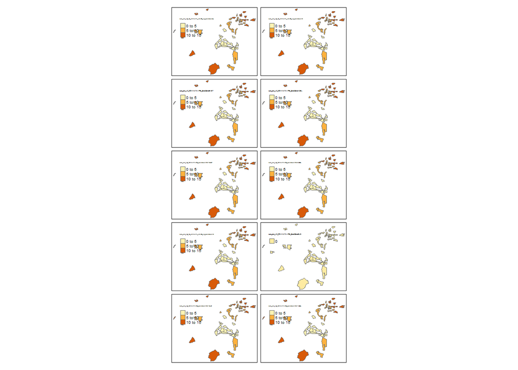

#### Auto time from Hybla Valley Zone 51510000036 for all skims

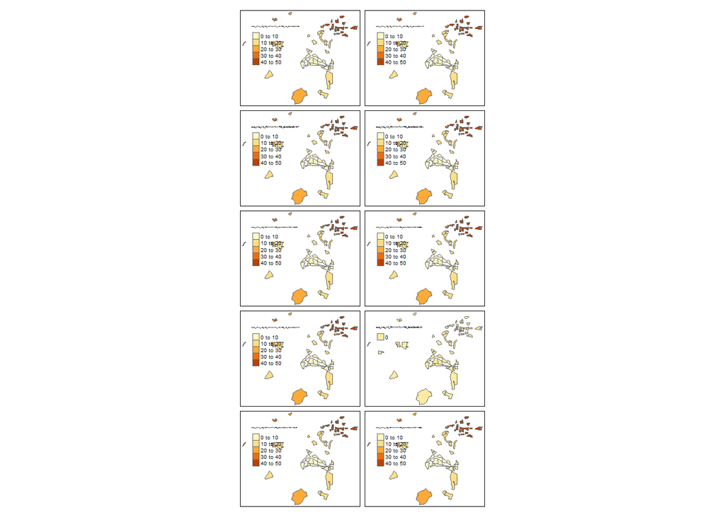

## Step 4: Summarize to district

# Results

The following tables present the final summarized results. These tables enable side-by-side comparisons between the various skim inputs of the mean distance and time values for each district-to-district pair.

## Complete district-to-district results

This table shows the mean value of zone-to-zone distance value for each district-to-district pair.

|  | A_DIST | P_DIST | AC_FC_40-WMATA_40-VRE_40_Zone2ZoneBLD- | AC_FC_40-WMATA_40-VRE_40_Zone2ZoneY2040BLD- | AC_FC-WMATA-VRE_Zone2ZoneEXST | AC_FC-WMATA-VRE_Zone2ZoneNOBL | AC_FC-WMATA-VRE_Zone2ZoneY2017EXST | AC_FC-WMATA-VRE_Zone2ZoneY2040NOBL | AC_FC_40-WMATA_40-VRE_40_Zone2ZoneY2017BLD- | AC_FC-WMATA-VRE_Zone2ZoneBLD- | AC_FC-WMATA-VRE_Zone2ZoneY2017BLD- | AC_FC-WMATA-VRE_Zone2ZoneY2017NOBL |
| --- | --- | --- | --- | --- | --- | --- | --- | --- | --- | --- | --- | --- |
| 1 | Annandale | Annandale | 1.53521126424763 | 1.53521126424763 | 1.53521126424763 | 1.53521126424763 | 1.53521126424763 | 1.53521126424763 | 1.53521126424763 | 0 | 1.53521126424763 | 1.53521126424763 |
| 2 | Annandale | Baileys | 4.38749998807907 | 4.38749998807907 | 4.38749998807907 | 4.38749998807907 | 4.38749998807907 | 4.38749998807907 | 4.38749998807907 | 0 | 4.38749998807907 | 4.38749998807907 |
| 3 | Annandale | Burke | 7.10400001525879 | 7.10400001525879 | 7.10400001525879 | 7.10400001525879 | 7.10400001525879 | 7.10400001525879 | 7.10400001525879 | 0 | 7.10400001525879 | 7.10400001525879 |
| 4 | Annandale | Centreville | 16.7636362422596 | 16.7636362422596 | 16.7636362422596 | 16.7636362422596 | 16.7636362422596 | 16.7636362422596 | 16.7636362422596 | 0 | 16.7636362422596 | 16.7636362422596 |
| 5 | Annandale | Columbia_Pke | 5.9 | 5.9 | 5.9 | 5.9 | 5.9 | 5.9 | 5.9 | 0 | 5.9 | 5.9 |
| 6 | Annandale | Cryst_City | 8.60000006357829 | 8.60000006357829 | 8.60000006357829 | 8.60000006357829 | 8.60000006357829 | 8.60000006357829 | 8.60000006357829 | 0 | 8.60000006357829 | 8.60000006357829 |
| 7 | Annandale | DC_Ana | 16.7000000476837 | 16.7000000476837 | 16.7000000476837 | 16.7000000476837 | 16.7000000476837 | 16.7000000476837 | 16.7000000476837 | 0 | 16.7000000476837 | 16.7000000476837 |
| 8 | Annandale | DC_Core | 10.5500001907349 | 10.5500001907349 | 10.5500001907349 | 10.5500001907349 | 10.5500001907349 | 10.5500001907349 | 10.5500001907349 | 0 | 10.5500001907349 | 10.5500001907349 |
| 9 | Annandale | DC_Rck_Crk | 14.7625000476837 | 14.7625000476837 | 14.7625000476837 | 14.7625000476837 | 14.7625000476837 | 14.7625000476837 | 14.7625000476837 | 0 | 14.7625000476837 | 14.7625000476837 |
| 10 | Annandale | Dranesville | 18.0000004768372 | 18.0000004768372 | 18.0000004768372 | 18.0000004768372 | 18.0000004768372 | 18.0000004768372 | 18.0000004768372 | 0 | 18.0000004768372 | 18.0000004768372 |

[output cut: 1144 more lines]

This table shows the mean value of zone-to-zone time value for each district-to-district pair.

|  | A_DIST | P_DIST | AC_FC_40-WMATA_40-VRE_40_Zone2ZoneBLD- | AC_FC_40-WMATA_40-VRE_40_Zone2ZoneY2040BLD- | AC_FC-WMATA-VRE_Zone2ZoneEXST | AC_FC-WMATA-VRE_Zone2ZoneNOBL | AC_FC-WMATA-VRE_Zone2ZoneY2017EXST | AC_FC-WMATA-VRE_Zone2ZoneY2040NOBL | AC_FC_40-WMATA_40-VRE_40_Zone2ZoneY2017BLD- | AC_FC-WMATA-VRE_Zone2ZoneBLD- | AC_FC-WMATA-VRE_Zone2ZoneY2017BLD- | AC_FC-WMATA-VRE_Zone2ZoneY2017NOBL |
| --- | --- | --- | --- | --- | --- | --- | --- | --- | --- | --- | --- | --- |
| 1 | Annandale | Annandale | 3.50028170498324 | 3.50028170498324 | 3.50028170498324 | 3.50028170498324 | 3.50028170498324 | 3.50028170498324 | 3.50028170498324 | 0 | 3.50028170498324 | 3.50028170498324 |
| 2 | Annandale | Baileys | 8.90687495470047 | 8.90687495470047 | 8.90687495470047 | 8.90687495470047 | 8.90687495470047 | 8.90687495470047 | 8.90687495470047 | 0 | 8.90687495470047 | 8.90687495470047 |
| 3 | Annandale | Burke | 23.3004000091553 | 23.3004000091553 | 23.3004000091553 | 23.3004000091553 | 23.3004000091553 | 23.3004000091553 | 23.3004000091553 | 0 | 23.3004000091553 | 23.3004000091553 |
| 4 | Annandale | Centreville | 47.2390910061923 | 47.2390910061923 | 47.2390910061923 | 47.2390910061923 | 47.2390910061923 | 47.2390910061923 | 47.2390910061923 | 0 | 47.2390910061923 | 47.2390910061923 |
| 5 | Annandale | Columbia_Pke | 11.5113334019979 | 11.5113334019979 | 11.5113334019979 | 11.5113334019979 | 11.5113334019979 | 11.5113334019979 | 11.5113334019979 | 0 | 11.5113334019979 | 11.5113334019979 |
| 6 | Annandale | Cryst_City | 15.7066666285197 | 15.7066666285197 | 15.7066666285197 | 15.7066666285197 | 15.7066666285197 | 15.7066666285197 | 15.7066666285197 | 0 | 15.7066666285197 | 15.7066666285197 |
| 7 | Annandale | DC_Ana | 43.1025009155273 | 43.1025009155273 | 43.1025009155273 | 43.1025009155273 | 43.1025009155273 | 43.1025009155273 | 43.1025009155273 | 0 | 43.1025009155273 | 43.1025009155273 |
| 8 | Annandale | DC_Core | 28.2299995422363 | 28.2299995422363 | 28.2299995422363 | 28.2299995422363 | 28.2299995422363 | 28.2299995422363 | 28.2299995422363 | 0 | 28.2299995422363 | 28.2299995422363 |
| 9 | Annandale | DC_Rck_Crk | 45.0925002098083 | 45.0925002098083 | 45.0925002098083 | 45.0925002098083 | 45.0925002098083 | 45.0925002098083 | 45.0925002098083 | 0 | 45.0925002098083 | 45.0925002098083 |
| 10 | Annandale | Dranesville | 39.7600002288818 | 39.7600002288818 | 39.7600002288818 | 39.7600002288818 | 39.7600002288818 | 39.7600002288818 | 39.7600002288818 | 0 | 39.7600002288818 | 39.7600002288818 |

[output cut: 1144 more lines]

## Focus areas district-to-district results as matrix

### Focus area 1

| Productions | Attractions |
| --- | --- |
| Mt_Vernon | DC_Ana |
| Centreville | DC_Core |
| Burke | Burke |
| Hybla_Vlly | DC_Rck_Crk |

#### Focus are 1 times

| A_DIST | AC_FC_40-WMATA_40-VRE_40_Zone2ZoneBLD- | AC_FC_40-WMATA_40-VRE_40_Zone2ZoneY2040BLD- | AC_FC-WMATA-VRE_Zone2ZoneEXST | AC_FC-WMATA-VRE_Zone2ZoneNOBL | AC_FC-WMATA-VRE_Zone2ZoneY2017EXST | AC_FC-WMATA-VRE_Zone2ZoneY2040NOBL | AC_FC_40-WMATA_40-VRE_40_Zone2ZoneY2017BLD- | AC_FC-WMATA-VRE_Zone2ZoneBLD- | AC_FC-WMATA-VRE_Zone2ZoneY2017BLD- | AC_FC-WMATA-VRE_Zone2ZoneY2017NOBL |
| --- | --- | --- | --- | --- | --- | --- | --- | --- | --- | --- |
| Burke | 4.31050 | 4.31050 | 4.31050 | 4.31050 | 4.31050 | 4.31050 | 4.31050 | 0 | 4.31050 | 4.31050 |
| Burke | 26.77714 | 26.77714 | 26.77714 | 26.77714 | 26.77714 | 26.77714 | 26.77714 | 0 | 26.77714 | 26.77714 |
| Burke | 31.27800 | 31.27800 | 31.27800 | 31.27800 | 31.27800 | 31.27800 | 31.27800 | 0 | 31.27800 | 31.27800 |
| DC_Ana | 67.39500 | 67.39500 | 67.39500 | 67.39500 | 67.39500 | 67.39500 | 67.39500 | 0 | 67.39500 | 67.39500 |
| DC_Ana | 94.75444 | 94.75444 | 94.75444 | 94.75444 | 94.75444 | 94.75444 | 94.75444 | 0 | 94.75444 | 94.75444 |
| DC_Ana | 40.64969 | 40.64969 | 40.64969 | 40.64969 | 40.64969 | 40.64969 | 40.64969 | 0 | 40.64969 | 40.64969 |
| DC_Ana | 47.85571 | 47.85571 | 47.85571 | 47.85571 | 47.85571 | 47.85571 | 47.85571 | 0 | 47.85571 | 47.85571 |
| DC_Core | 70.60020 | 70.60020 | 70.60020 | 70.60020 | 70.60020 | 70.60020 | 70.60020 | 0 | 70.60020 | 70.60020 |
| DC_Core | 92.55471 | 92.55471 | 92.55471 | 92.55471 | 92.55471 | 92.55471 | 92.55471 | 0 | 92.55471 | 92.55471 |
| DC_Core | 48.46424 | 48.46424 | 48.46424 | 48.46424 | 48.46424 | 48.46424 | 48.46424 | 0 | 48.46424 | 48.46424 |
| DC_Core | 55.59966 | 55.59966 | 55.59966 | 55.59966 | 55.59966 | 55.59966 | 55.59966 | 0 | 55.59966 | 55.59966 |
| DC_Rck_Crk | 74.08059 | 74.08059 | 74.08059 | 74.08059 | 74.08059 | 74.08059 | 74.08059 | 0 | 74.08059 | 74.08059 |
| DC_Rck_Crk | 91.56214 | 91.56214 | 91.56214 | 91.56214 | 91.56214 | 91.56214 | 91.56214 | 0 | 91.56214 | 91.56214 |
| DC_Rck_Crk | 53.85293 | 53.85293 | 53.85293 | 53.85293 | 53.85293 | 53.85293 | 53.85293 | 0 | 53.85293 | 53.85293 |
| DC_Rck_Crk | 60.00202 | 60.00202 | 60.00202 | 60.00202 | 60.00202 | 60.00202 | 60.00202 | 0 | 60.00202 | 60.00202 |

### Focus area 2

| Productions | Attractions |
| --- | --- |
| DC_Ana | DC_Ana |
| DC_Core | DC_Core |
| DC_Rck_Cr | DC_Rck_Cr |

| A_DIST | AC_FC_40-WMATA_40-VRE_40_Zone2ZoneBLD- | AC_FC_40-WMATA_40-VRE_40_Zone2ZoneY2040BLD- | AC_FC-WMATA-VRE_Zone2ZoneEXST | AC_FC-WMATA-VRE_Zone2ZoneNOBL | AC_FC-WMATA-VRE_Zone2ZoneY2017EXST | AC_FC-WMATA-VRE_Zone2ZoneY2040NOBL | AC_FC_40-WMATA_40-VRE_40_Zone2ZoneY2017BLD- | AC_FC-WMATA-VRE_Zone2ZoneBLD- | AC_FC-WMATA-VRE_Zone2ZoneY2017BLD- | AC_FC-WMATA-VRE_Zone2ZoneY2017NOBL |
| --- | --- | --- | --- | --- | --- | --- | --- | --- | --- | --- |

### Focus area 3

| Productions | Attractions |
| --- | --- |
| Hybla | DC_Core |

| A_DIST | AC_FC_40-WMATA_40-VRE_40_Zone2ZoneBLD- | AC_FC_40-WMATA_40-VRE_40_Zone2ZoneY2040BLD- | AC_FC-WMATA-VRE_Zone2ZoneEXST | AC_FC-WMATA-VRE_Zone2ZoneNOBL | AC_FC-WMATA-VRE_Zone2ZoneY2017EXST | AC_FC-WMATA-VRE_Zone2ZoneY2040NOBL | AC_FC_40-WMATA_40-VRE_40_Zone2ZoneY2017BLD- | AC_FC-WMATA-VRE_Zone2ZoneBLD- | AC_FC-WMATA-VRE_Zone2ZoneY2017BLD- | AC_FC-WMATA-VRE_Zone2ZoneY2017NOBL |
| --- | --- | --- | --- | --- | --- | --- | --- | --- | --- | --- |

### Focus area 4

- Note: Unable to find district match for “Hunin” district in STOPS PRN Reprot tables. *

| Productions | Attractions |
| --- | --- |
| Burke | Burke |

#### Focus are 4 times

| A_DIST | AC_FC_40-WMATA_40-VRE_40_Zone2ZoneBLD- | AC_FC_40-WMATA_40-VRE_40_Zone2ZoneY2040BLD- | AC_FC-WMATA-VRE_Zone2ZoneEXST | AC_FC-WMATA-VRE_Zone2ZoneNOBL | AC_FC-WMATA-VRE_Zone2ZoneY2017EXST | AC_FC-WMATA-VRE_Zone2ZoneY2040NOBL | AC_FC_40-WMATA_40-VRE_40_Zone2ZoneY2017BLD- | AC_FC-WMATA-VRE_Zone2ZoneBLD- | AC_FC-WMATA-VRE_Zone2ZoneY2017BLD- | AC_FC-WMATA-VRE_Zone2ZoneY2017NOBL |
| --- | --- | --- | --- | --- | --- | --- | --- | --- | --- | --- |
| Burke | 4.3105 | 4.3105 | 4.3105 | 4.3105 | 4.3105 | 4.3105 | 4.3105 | 0 | 4.3105 | 4.3105 |